# Synthetic Control Method

## Synthetic Control Method

## Single Treated Unit

- DID requires estimating: \[ \begin{split} \tau_{DID} &= [\mathbb{E}(Y_i| G_i = 1, T_i = 1) - \mathbb{E}(Y_i| G_i = 1, T_i = 0)] \\ &- [\mathbb{E}(Y_i| G_i = 0, T_i = 1) - \mathbb{E}(Y_i| G_i = 0, T_i = 0)]. \end{split} \]
- This requires multiple treated units and multiple control units.
- Even if there is only one treated unit, if there are long enough multiple periods before the treatment, one may be able to use **synthetic control method**.

## Setting

- Imagine \(2 \times T\) design of DID.
- There are \(i = 1, \cdots, N + 1\) units.
- *Only the first unit \(i = 1\) is treated* since period \(T_0 + 1\):
  - \(G_i = 1\{i = 1\}\).
  - \(D_{it} = G_i \cdot 1\{t > T_0\}\).
- Units of \(i = 2, \cdots, N + 1\) are a set of potential comparisons.
- For each \(i\), we observe the outcome of interest for \(t = 1, \cdots T\):
  - \(Y_{it} = D_{it}Y^\ast_{it}(1)+(1 - D_{it})Y^\ast_{it}(0)\).
- For each \(i\), we also observe a set of \(K\) predictors of the outcomes:
  - \(X_{1i}, \cdots , X_{Ki}\).
  - This may include the pre-intervention values of \(Y_{it}\) for \(t \le T_0\).

## Estimand

- The effect of intervention of interest for the affected unit in period \(t > T_0\): \[ \tau_{1t} = Y^\ast_{1t}(1) - Y^\ast_{1t}(0). \]
- Not average.
- How do we estimate \(Y^\ast_{1t}(0)\)?
- This is by nature a *case study*.

## Card (1990)’s case study

- Intervention: The massive arrival of Cuban expatriates to Miam during the 1980 Mariel boatlift.
- \(i = 1\): Miami.
- \(i = 2, \cdots, N + 1\): Atlanta, Los Angeles, Houston, and Tampa-St. Petersburg.
- \(Y_{it}\): Native unemployment.

> These four cities were selected both because they had relatively large populations of blacks and Hispanics and because they exhibited a pattern of economic growth similar to that in Miami over the late 1970s and early 1980s. (p.249)
- How to formalize this selection?

## Constructing a synthetic control

- Find a weight \(w_i, i = 2, \cdots, N + 1\).
- Construct a **synthetic control estimator** of \(Y^\ast_{1t}(0)\) for \(t > T_0\) by: \[ \hat{Y}_{1t}(0) = \sum_{i = 2}^{N + 1} w_i Y_{it}. \]
- Construct a **synthetic control estimator** of \(\tau_{1t}\) for \(t > T_0\) by: \[ \hat{\tau}_{1t} = Y_{1t} - \hat{Y}_{1t}(0). \]

## Restricting the weights

- The weights are restricted to be **non-negative and sum up to 1**.
- This ensures that \(\hat{Y}_{1t}(0)\) is an interpolation of \(Y_{it}\) for \(i = 2, \cdots, N + 1\).
- A negative value or a value greater than 1 means an extrapolation of the observation.
- We will need to rescale the data to correct the differences in the size between units (e.g., per capita income).

## Manual weighting

- Simple average with \(w_i = 1/N\): \[ \hat{Y}_{1t}(0) = \frac{1}{N} \sum_{i = 2}^{N + 1}Y_{it}. \]
- Population-weighted average with \(w_i = w_i^{pop}\): \[ \hat{Y}_{1t}(0) = \sum_{i = 2}^{N + 1} w_i^{pop} Y_{it}. \]

## Abadie, Diamond, and Hainmuller (2010)’s proposal

- Choose the weight by minimizing a distance between predictors: \[ \min_{w} \sum_{k = 1}^K v_k\Big(X_{k1} - \sum_{i = 2}^{N + 1} w_i X_{ik} \Big)^2 \] subject to: \[ w_i \ge 0, \sum_{i = 2}^{N + 1} w_i = 1, \] with positive constants \(v_k\) for \(k = 1, \cdots, K\) as hyper parameters.

## Training, validation, and test samples

1. Divide the pre-intervention periods into:
   - Initial *training* period (\(t = 1, \cdots, t_0\));
   - Subsequent *validation* periods (\(t = t_0 + 1, \cdots, T_0\)).
   - For each \(v\), define \(w_i(v)\) as the minimizer given \(v\).
   - Compute: \[ \sum_{t = t_0 + 1}^{T_0} \Big(Y_{1t} - \sum_{i = 2}^{N + 1} w_i(v) Y_{it} \Big)^2. \]
   - Pick \(v\) that minimize this and denote by \(v^*\).
2. Use \(w^* = w(v^*)\) as the weight.

## Justification in Abadie et al. (2010)

- Need a *functional-form assumption* on the potential outcome model.
- Suppose that the control outcome follows a *linear factor model*: \[ Y^\ast_{it}(0) = \delta_t + \theta_t Z_i + \lambda_t \mu_i + \epsilon_{it}, \] where:
- \(\delta_t\): time trend.
- \(Z_i\) and \(\mu_i\): observed and unobserved factor loading.
- \(\theta_t\) and \(\lambda_t\): unobserved common factors.
- \(\epsilon_{it}\): mean 0 i.i.d. shocks (can be generalized).
- Intuitively, SCM tries to replicate \(\lambda_t \mu_i\) by weighting.

## Justification in Abadie et al. (2010)

- Suppose that there exist a weight \(w^\ast\) such that: \[ \sum_{i = 2}^{N + 1} w_i^\ast Y_{it}^\ast(0) = Y_{1t}^\ast(0), t = 1, \cdots, T_0, \] and \[ \sum_{i = 2}^{N + 1} w_i^\ast Z_i = Z_1. \]

## Justification in Abadie et al. (2010)

- Then, the prediction error at \(t < T_0\) is: \[ \begin{split} &Y_{1t}^\ast(0) - \sum_{i = 2}^{N + 1} w_i^\ast Y_{it}\\ &=\theta_t\left(Z_1 - \sum_{i = 2}^{N + 1} w_i^\ast Z_i\right)\\ &+\lambda_t \left(\mu_1 - \sum_{i = 2}^{N + 1} w_i^\ast \mu_i \right)\\ &+\sum_{i = 2}^{N + 1} w_i^\ast (\epsilon_{1t} - \epsilon_{it}). \end{split} \]

## Justification in Abadie et al. (2010)

- For the control period \(t = 1, \cdots, T_0\): \[ \begin{split} &\mathbf{Y}_1 - \sum_{i = 2}^{N + 1} w_i^\ast \mathbf{Y}_i\\ &= \boldsymbol{\theta}\left(Z_1 - \sum_{i = 2}^{N + 1} w_i^\ast Z_i\right)\\ &+ \boldsymbol{\lambda} \left(\mu_1 - \sum_{i = 2}^{N + 1} w_i^\ast \mu_i \right)\\ &+\sum_{i = 2}^{N + 1} w_i^\ast (\boldsymbol{\epsilon}_1 - \boldsymbol{\epsilon}_i). \end{split} \]

## Justification in Abadie et al. (2010)

- Solving the previous equation for the unobserved term gives: \[ \begin{split} \left(\mu_1 - \sum_{i = 2}^{N + 1} w_i^\ast \mu_i \right) & = (\boldsymbol{\lambda}' \boldsymbol{\lambda})^{-1} \boldsymbol{\lambda}' \left(\mathbf{Y}_1 - \sum_{i = 2}^{N + 1} w_i^\ast \mathbf{Y}_i\right)\\ &- (\boldsymbol{\lambda}' \boldsymbol{\lambda})^{-1} \boldsymbol{\lambda}' \boldsymbol{\theta}\left(Z_1 - \sum_{i = 2}^{N + 1} w_i^\ast Z_i\right) \\ &- (\boldsymbol{\lambda}' \boldsymbol{\lambda})^{-1} \sum_{i = 2}^{N + 1} w_i^\ast (\boldsymbol{\epsilon}_1 - \boldsymbol{\epsilon}_i)\\ &= - (\boldsymbol{\lambda}' \boldsymbol{\lambda})^{-1} \sum_{i = 2}^{N + 1} w_i^\ast (\boldsymbol{\epsilon}_1 - \boldsymbol{\epsilon}_i). \end{split} \]

## Justification in Abadie et al. (2010)

- Inserting this into the prediction error gives: \[ \begin{split} &Y_{1t}^\ast(0) - \sum_{i = 2}^{N + 1} w_i^\ast Y_i\\ &= - \lambda_t (\boldsymbol{\lambda}' \boldsymbol{\lambda})^{-1} \boldsymbol{\lambda}' \sum_{i = 2}^{N + 1} w_i^\ast (\boldsymbol{\epsilon}_1 - \boldsymbol{\epsilon}_i) +\sum_{i = 2}^{N + 1} w_i^\ast (\epsilon_{1t} - \epsilon_{it}). \end{split} \]

## Justification in Abadie et al. (2010)

\[ \begin{split} &= - \lambda_t (\boldsymbol{\lambda}' \boldsymbol{\lambda})^{-1} \boldsymbol{\lambda}' \boldsymbol{\epsilon}_1\\ &+ \lambda_t (\boldsymbol{\lambda}' \boldsymbol{\lambda})^{-1} \boldsymbol{\lambda}' \sum_{i = 2}^{N + 1} w_i^\ast \boldsymbol{\epsilon}_i \\ & +\sum_{i = 2}^{N + 1} w_i^\ast (\epsilon_{1t} - \epsilon_{it}) \end{split} \]

- The first term is mean zero because \(\boldsymbol{\epsilon}_1\) has mean zero conditional on \(\boldsymbol{\lambda}\).
- The third term is mean zero because \(w_i^\ast\) contains information on \(t \le T_0\) and is independent of errors at \(t > T_0\).
- The second term may not be mean zero: bias term because \(w_i^\ast\) and \(\boldsymbol{\epsilon}_i\) are correlated.

## Justification in Abadie et al. (2010)

- Suppose that the \(p\)-th moment of \(|\epsilon_{it}|\) exists.
- Let \(m_{p,it} = \mathbb{E}|\epsilon_{it}|^p\), \(m_{p,i} = 1/T_0 \sum_{t = 1}^{T_0} m_{p, it}\), \(\overline{m}_p = \max_{i = 2, \cdots, N + 1} m_{p, i}\).
- Then, we can bound the bias by: \[ \mathbb{E}|bias_t| \lesssim \max\{\frac{\overline{m}_p^{1/p}}{T_0^{1 - 1/p}}, \frac{\overline{m}_2^{1/2}}{T_0^{1/2}}\}. \]
- The bias is smaller if:
  - Pre-treatment period \(T_0\) is longer.
  - The standard deviations of the idiosyncratic shocks are smaller.

## Justification in Abadie et al. (2010)

- Then, should we just take a long enough pre-treatment period?
  - Not necessarily true, because the model is more likely to be misspecified if the data goes back to the past.
  - Then, the assumption of the presence of perfect-match \(w_i^*\) will be violated.
- Limitations:
  - It relies on the functional-form assumption on the potential outcome model.
  - It relies on the assumption that \(w_i^\ast\) exists, which may not be true.
  - It does not allow an inference based on the sampling-based uncertainty.

## Calculate p-value

- Use a randomization test.
- Abadie et al. (2010) suggest a test statistics measuring the ratio of post-treatment fit relative to the pre-intervention fit.
- Consider a placebo treatment to unit \(i\) and \(\hat{Y}_{it}(0)\) is the SC estimator of \(Y^\ast_{it}(0)\) for \(t > T_0\).
- Consider: \[ R_i(t_1, t_2) = \Bigg(\frac{1}{t_2 - t_1 + 1} \sum_{t = t_1}^{t_2} [Y_{it} - \hat{Y}_{it}(0)]^2 \Bigg)^{1/2}, \] \[ r_i = \frac{R_i(T_0 + 1, T)}{R_i(1, T_0)}. \]

## Calculate p-value

- Then, calculate the p-value of the sharp null hypothesis \(\tau_{it} = 0\) for \(i = 1, \cdots, N + 1\) and \(t = 1, \cdots, T\) is: \[ p = \frac{1}{N + 1} \sum_{i = 1}^{N + 1}1\{r_i \ge r_1\}. \]
- Remember that SCM was a formalization of a case study.
- Without the formalization, we could not apply the “same procedure” to estimate the placebo statistics.
- In this sense, this inference became possible only by the formalization of SCM.

## Visualize placebo effects Figure 4 of Abadie et al. (2010)

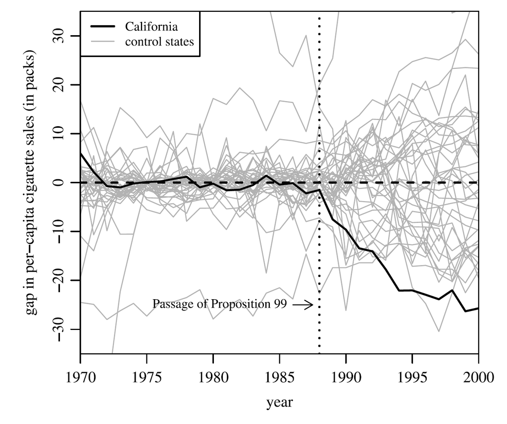

## Visualize placebo effects

- Exclude states that had a pre-treatment mean-squared prediction error (MSPE) is more than 20 times the treated state’s MSPE.Figure 5 of Abadie et al. (2010)

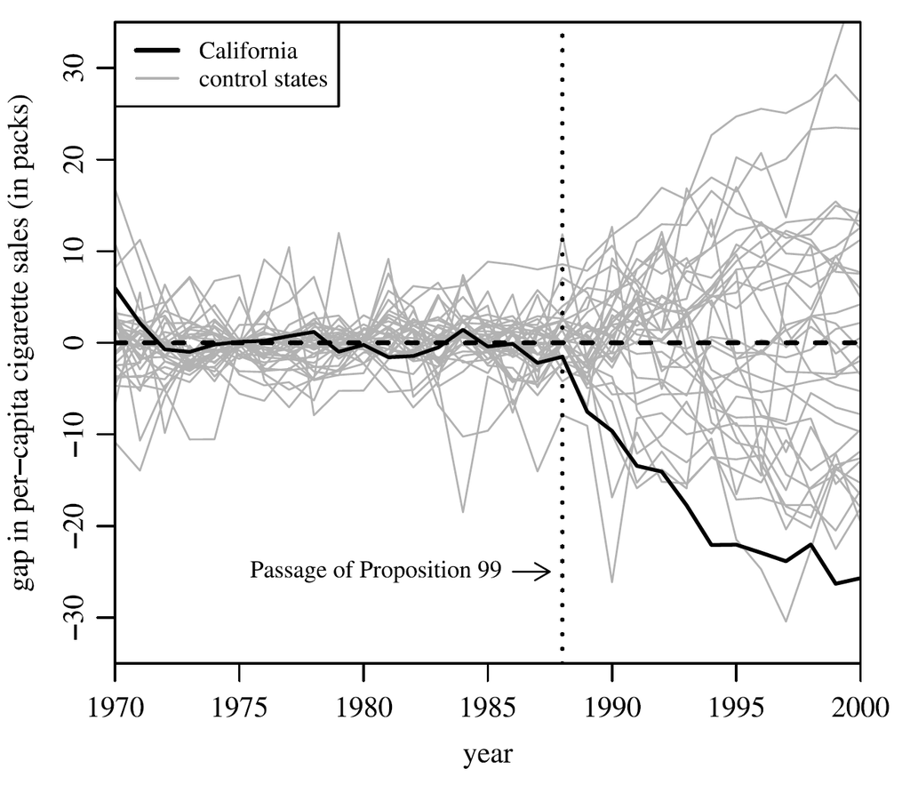

## Advantages of SCM

- No extrapolation.
- Transparency of fit.
  - If comparison group are not appropriate, the pre-treatment fit shows this.
- Safeguard against specification searches.
  - It does not use the post-treatment data for constructing weights.
- Transparency of the counterfactual.
  - Weights can be interpreted by domain knowledge.

## Checklist

- The treatment effect should be large enough.
- Similar enough comparison group should exist.
- No anticipation should hold.
- No spillover effects.

## Validation tests

- Backdating: Set placebo \(T_0\) and repeat the same analysis.Figure 3 of Abadie (2021)

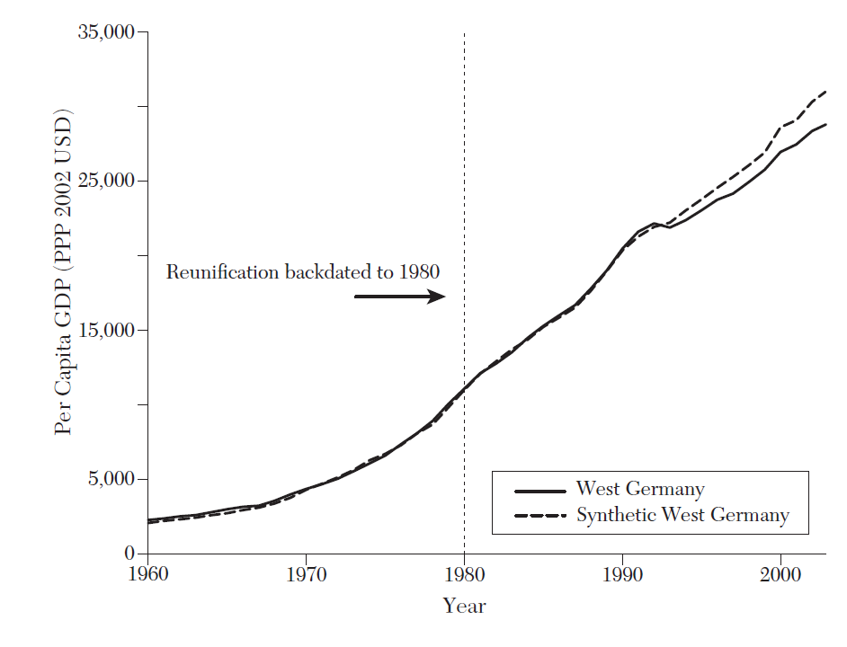

## Robustness checks

- Change donor pool.
- Change predictors.

## Regularization

- The minimization problem for finding weights often has multiple solutions.
- This is especially true when we extend the analysis to multiple treated units.
- Abadie and L’Hour (2021) proposes the following penalized estimator: \[ \min_{w} \sum_{k = 1}^K v_k\Big(X_{k1} - \sum_{i = 2}^{N + 1} w_i X_{ik} \Big)^2 + \lambda \sum_{i = 2}^{N + 1} w_i \sum_{k = 1}^K v_k (X_{1k} - X_{ik})^2 \] subject to: \[ w_i \ge 0, \sum_{i = 2}^{N + 1} w_i = 1, \]
- The penalty \(\lambda\) can be chosen by validation data as well as \(v\).

## Synthetic Difference-in-Differences

## Weighted double-differencing estimators

- Consider \(2 \times T\) DID design.
- For simplicity, consider no covariate.
- There are \(N\) units and \(T\) periods.
- There can be multiple treated units.
- \(i = 1, \cdots, N_0\) are control and \(i = N_0 + 1, \cdots N\) is treated, with \(N_1 = N - N_0\).
- Treatment is assigned on \(T_0 + 1\) with \(T_1 = T - T_0\).
- We estimate the average treatment effect on treated by a class of **weighted double-differencing estimators**: \[ \hat{\tau} = \frac{1}{N_1} \sum_{i = N_0 + 1}^N \hat{\delta}_i - \sum_{i = 1}^{N_0} \hat{w}_i \hat{\delta}_i. \]

## SC estimator of the average treatment effect on treated

- \(\hat{\delta}_i\) is calculated as: \[ \hat{\delta}_i^{sc} = \frac{1}{T_1} \sum_{t = T_0 + 1} Y_{it}. \]
- \(\hat{w}_i\) is constructed according to the SCM as \(\hat{w}^{sc}\).

## DID estimator of the average treatment effect on treated

- \(\hat{\delta}_i\) is calculated as: \[ \hat{\delta}_i^{did} = \frac{1}{T_1} \sum_{t = T_0 + 1} Y_{it} - \frac{1}{T_0} \sum_{t = 1}^{T_0} Y_{it}. \]
- \(\hat{w}_i\) is constructed as \(\hat{w}^{did} = 1/N_0\).

## Synthetic DID estimator

- Arkhangelsky et al. (2021) propose a **synthetic DID estimator** that combines the features of SCM and DID and adding extra features as follows.
- \(\hat{\delta}_i\) is calculated as: \[ \hat{\delta}_i^{sdid} = \frac{1}{T_1} \sum_{t = T_0 + 1} Y_{it} - \sum_{t = 1}^{T_0} \hat{\lambda}_t^{sdid} Y_{it}, \] which borrows the first-differencing from DID and augments by allowing for a flexible time weight \(\hat{\lambda}_t^{sdid}\) instead of \(1/T_0\).
- \(\hat{w}_i\) is constructed according to a procedure similar to the SCM as \(\hat{w}^{sdid}\).

## Synthetic DID: algorithm

- Obtain unit weight \(\hat{w}_i^{sdid}\) and level adjustment \(\hat{w}_0\) by solving the constrained minimization problem: \[ \min_{w_0, w} \sum_{t = 1}^{T_0}(w_0 + \sum_{i = 1}^{N_0} w_i Y_{it} - \frac{1}{N_1} \sum_{i = N_0 + 1}^N Y_{it})^2 + \zeta^2 T_0 \sum_{i = 1}^N w_i^2, \] subject to: \[ w_i \ge 0, \sum_{i = 1}^{N_0} w_i = 1. \]
- Allowing for a level difference \(w_0\) is different from SCM.
- Ridge penalty instead of lasso penalty (minor).

## Synthetic DID: algorithm

- Obtain time weight \(\hat{\lambda}_t^{sdid}\) and level adjustment \(\hat{\lambda}_0\) by solving the constrained minimization problem: \[ \min_{\lambda_0, \lambda} \sum_{i = 1}^{N_0} (\lambda_0 + \sum_{t = 1}^{T_0} \lambda_t Y_{it} - \frac{1}{T_1} \sum_{t = T_0 + 1}^T Y_{it})^2, \] subject to: \[ \lambda_t \ge 0, \sum_{t = 1}^{T_0} \lambda_t = 1. \]

## Synthetic DID: algorithm

- They suggest to set the ridge penalty \(\zeta\) at: \[ \zeta = (N_1 T_1)^{1/4} \hat{\sigma}, \] \[ \hat{\sigma}^2 = \frac{1}{N_0(T_0 - 1)} \sum_{i = 1}^{N_0} \sum_{t = 1}^{T_0 - 1} (\Delta_{it} - \overline{\Delta})^2, \] \[ \Delta_{it} = Y_{i, t + 1} - Y_{it}, \] \[ \overline{\Delta} = \frac{1}{N_0(T_0 - 1)} \sum_{i = 1}^{N_0} \sum_{t = 1}^{T_0 - 1} \Delta_{it}. \]

## DID in California smoking cessation programFigure 1 of Arkhangelsky et al. (2021)

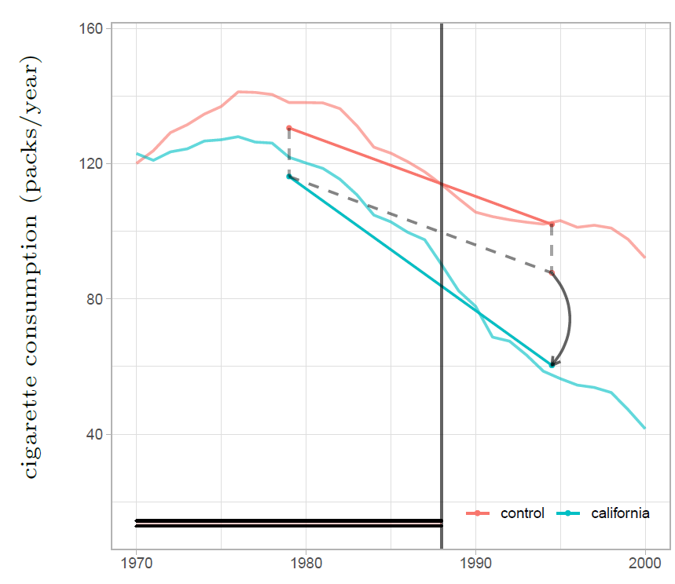

- DID puts an equal weight across units and time.
- Because the pre-trend is different, DID is dubious.

## SCM in California smoking cessation programFigure 1 of Arkhangelsky et al. (2021)

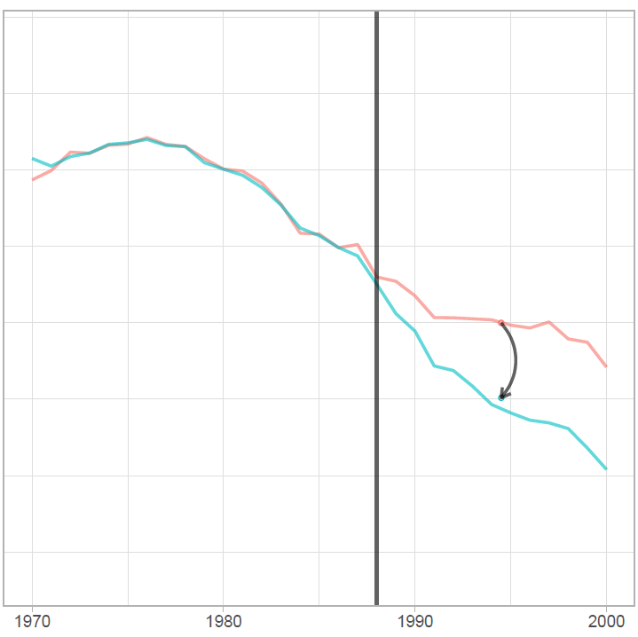

- SCM puts weights on a few states.
- Synthetic control targets both level and trend.

## SDID in California smoking cessation programFigure 1 of Arkhangelsky et al. (2021)

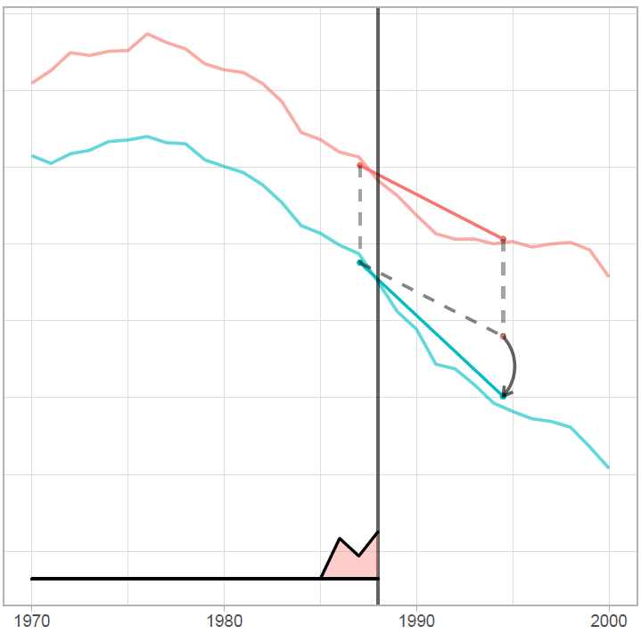

- Re-weight units and time.
- Then, apply DID to the re-weighted unit.
- Synthetic control only targets the trend.

## Justification

- Suppose that the control outcome follows a linear factor model: \[ Y^\ast_{it}(0) = \delta_t + \theta_t Z_i + \lambda_t \mu_i + \epsilon_{it}. \]
- Synthetic DID works if the combination of i) double differencing, ii) the unit re-weighting, and iii) the time re-weighting enables us to trace out \(\lambda_t \mu_i\).
- Formal asymptotic result is found in Arkhangelsky et al. (2021).

## Inference

- If multiple units are treated, we can use a block bootstrap for inference.
- If only one unit is treated, we can use a randomization test.

## Reference

- Abadie, Alberto. 2021. “Using Synthetic Controls: Feasibility, Data Requirements, and Methodological Aspects.” Journal of Economic Literature 59 (2): 391–425.
- Abadie, Alberto, Alexis Diamond, and Jens Hainmueller. 2010. “Synthetic Control Methods for Comparative Case Studies: Estimating the Effect of California’s Tobacco Control Program.” Journal of the American Statistical Association. https://doi.org/10.1198/jasa.2009.ap08746.
- Abadie, Alberto, Alexis Diamond, and Jens Hainmueller. 2011. “Synth: An R Package for Synthetic Control Methods in Comparative Case Studies,” June. https://dspace.mit.edu/handle/1721.1/71234?show=full.
- Abadie, Alberto, and Javier Gardeazabal. 2003. “The Economic Costs of Conflict: A Case Study of the Basque Country.” The American Economic Review 93 (1): 113–32.

## Reference

- Abadie, Alberto, and Jérémy L’Hour. 2021. “A Penalized Synthetic Control Estimator for Disaggregated Data.” Journal of the American Statistical Association, August, 1–18.
- Arkhangelsky, Dmitry, Susan Athey, David A. Hirshberg, Guido W. Imbens, and Stefan Wager. n.d. “Synthetic Difference in Differences.” The American Economic Review. Accessed September 2, 2021. https://doi.org/10.1257/aer.20190159.
- “Synthdid Introduction.” n.d. Accessed November 13, 2021. https://synth-inference.github.io/synthdid/articles/synthdid.html.